# DemoKin: An R package to compute kinship networks in stable and non-stable populations

Ivan Williams (Universidad de Buenos Aires) Diego Alburez-Gutierrez* (Max Planck Institute for Demographic Research)

Formal Demography Working Group - Feb 25 2022

> **Get the `Rmd` version of this file: https://github.com/alburezg/kinship_formal_demo.**

# 1 The DemoKin package

`DemoKin` uses matrix demographic methods to compute expected (average) kin counts from demographic rates under a range of scenarios and assumptions. The package is an R-language implementation of Caswell (2019; 2021) and draws on previous theoretical development by Goodman, Keyfitz and Pullum (1974).

## 1.1 Installation

You can install the development version from GitHub with:

```r
# install.packages("devtools")
devtools::install_github("IvanWilli/DemoKin")
```

## 1.2 The function `kins()`

`DemoKin::kins()` currently does most of the heavy lifting in terms of implementing matrix kinship models. This is what it looks like in action, in this case assuming demographic stability:

```r
library(DemoKin)

stable <-
  kins(
    U = swe_surv
    , f = swe_asfr
    , stable = TRUE
    , ego_year = 1950
    , selected_kins = NULL
    , living = TRUE
    )
```

### 1.2.1 Arguments

Note that `DemoKin` only requires period demographic rate data as input!

### 1.2.2 Details

Relatives for the `selected_kins` argument are identified by a unique code:

| Code | Relative |
| --- | --- |
| coa | Cousins from older aunt |
| cya | Cousins from younger aunt |
| d | Daughter |
| gd | Grand-daughter |
| ggd | Great-grand-daughter |
| ggm | Great-grandmother |
| gm | Grandmother |
| m | Mother |
| nos | Nieces from older sister |
| nys | Nieces from younger sister |
| oa | Aunt older than mother |
| ya | Aunt younger than mother |
| os | Older sister |
| ys | Younger sister |

## 1.3 Built-in data

The `DemoKin` package includes data from Sweden as an example. The data comes from the [Human Mortality Database](https://www.mortality.org/) and [Human Fertility Database](https://www.humanfertility.org/). These datasets were loaded using the`DemoKin::get_HMDHFD` function. To list the data:

```r
data(package="DemoKin")
```

| Item | Title |
| --- | --- |
| swe_asfr | Swedish age-specific fertility rates from 1900 to 2015 |
| swe_pop | Female swedish population from 1900 to 2015 |
| swe_surv | Female swedish survival ratios from 1900 to 2015 |

The in-built data sets are:

- **swe_surv** matrix; survival ratio by age (DemoKin’s *U* argument)

This is what the data looks like:

```r
swe_surv[1:4, 1:4]
```

```
##        1900      1901      1902      1903
## 2 0.9566306 0.9555890 0.9624144 0.9611063
## 3 0.9786518 0.9792724 0.9807146 0.9818320
## 4 0.9875967 0.9876130 0.9885345 0.9897997
## 5 0.9907708 0.9904054 0.9915360 0.9923815
```

And plotted over time and age:

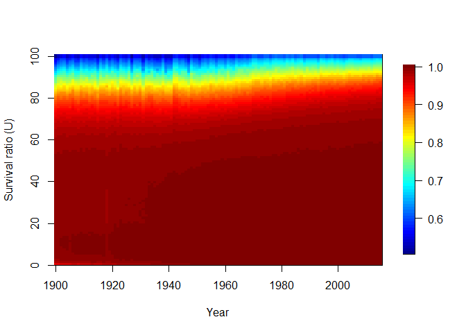

```r
library(fields)

image.plot(
  x = as.numeric(colnames(swe_surv))
  , y = 0:nrow(swe_surv)
  , z = t(as.matrix(swe_surv))
  , xlab = "Year"
  , ylab = "Survival ratio (U)"
  )
```

- **swe_asfr** matrix; age specific fertility rate (DemoKin’s *f* argument)

This is what the data looks like:

```r
swe_asfr[1:4, 1:4]
```

```
##   1900 1901 1902 1903
## 1    0    0    0    0
## 2    0    0    0    0
## 3    0    0    0    0
## 4    0    0    0    0
```

And plotted over time and age:

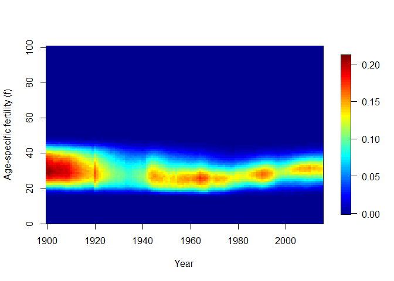

```r
image.plot(
  x = as.numeric(colnames(swe_asfr))
  , y = 0:nrow(swe_asfr)
  , z = t(as.matrix(swe_asfr))
  , xlab = "Year"
  , ylab = "Age-specific fertility (f)"
  )
```

- **swe_pop** matrix; population by age (Demokin’s *N* argument)

This is what the data looks like:

```r
swe_pop[1:4, 1:4]
```

```
## # A tibble: 4 x 4
##   `1900` `1901` `1902` `1903`
##    <dbl>  <dbl>  <dbl>  <dbl>
## 1  60917  62601  63337  63500
## 2  58927  57549  59573  60627
## 3  56823  57590  56426  58381
## 4  56473  55916  56887  55669
```

And plotted over time and age:

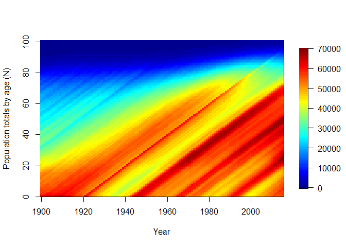

```r
image.plot(
  x = as.numeric(colnames(swe_pop))
  , y = 0:nrow(swe_pop)
  , z = t(as.matrix(swe_pop))
  , xlab = "Year"
  , ylab = "Population totals by age (N)"
  )
```

## 1.4 Value

`DemoKin::kins()` returns a list with two elements.

```r
head(stable$kins_by_age_ego)
```

```
## # A tibble: 6 x 7
##    year cohort age_ego kin   total mean_age sd_age
##   <dbl>  <dbl>   <int> <chr> <dbl>    <dbl>  <dbl>
## 1     0      0       0 coa   0.402    10.2    7.42
## 2     0      0       0 cya   0.134     5.04   4.42
## 3     0      0       0 d     0       NaN    NaN
## 4     0      0       0 gd    0       NaN    NaN
## 5     0      0       0 ggd   0       NaN    NaN
## 6     0      0       0 ggm   0.327    73.9    7.17
```

```r
head(stable$kins)
```

```
##   kin age_kin alive age_ego count cohort year
## 1   d       0   yes       0     0      0    0
## 2   d       1   yes       0     0      0    0
## 3   d       2   yes       0     0      0    0
## 4   d       3   yes       0     0      0    0
## 5   d       4   yes       0     0      0    0
## 6   d       5   yes       0     0      0    0
```

We’ll see what these means in the examples below.

# 2 Example 1: kin counts in stable populations

Following Caswell (2019), we assume a female closed population in which everyone experiences the Swedish 1950 mortality and fertility rates at each age throughout their life. We then ask:

> How can we characterize the kinship network of an average member of the population (call her ‘Ego’)?

For this exercise, we’ll use the Swedish data pre-loaded with `DemoKin`.

```r
library(DemoKin)

system.time(
  stable <-
  kins(
    ego_year = 1950
    , U = swe_surv
    , f = swe_asfr
    , stable = TRUE
    )
)
```

```
##    user  system elapsed
##    0.73    0.03    0.77
```

## 2.1 ‘Keyfitz’ kinship diagram

We can visualize the implied kin counts for an Ego aged 35 yo in a stable population using a network or ‘Keyfitz’ kinship diagram (Keyfitz and Caswell 2005) using the `plot_diagram` function:

```r
stable$kins_by_age_ego %>%
  filter(age_ego == 35) %>%
  select(kin, total) %>%
  plot_diagram()
```

[interactive chart not shown]

## 2.2 Expected kin counts for an Ego surviving to each age

before showing the results, we define a simple function to identify relatives based on their respective codes. The kinship codes (e.g., “gm”, “ggm”) are useful for filtering the data but confusing for visualisation.

```r
rename_kin <- function(df){
  df$kin <- relatives[df$kin]
  df
}
```

Now, let’s visualize how the expected number of daughters, siblings, cousins, etc., changes over the lifecourse of Ego.

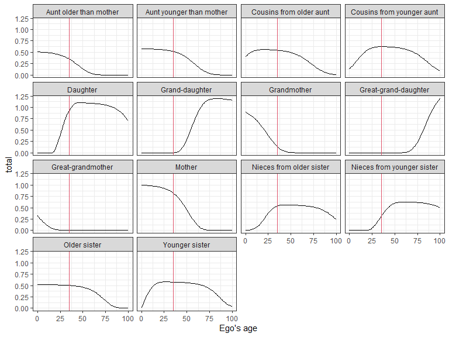

```r
stable$kins_by_age_ego %>%
  rename_kin() %>%
  ggplot() +
  geom_line(aes(age_ego, total))  +
  geom_vline(xintercept = 35, color=2)+
  theme_bw() +
  labs(x = "Ego's age") +
  facet_wrap(~kin)
```

It’s a bit too much information in one graph. Let’s pick it appart by considering different kin types in isolation.

- **Living ancestors**

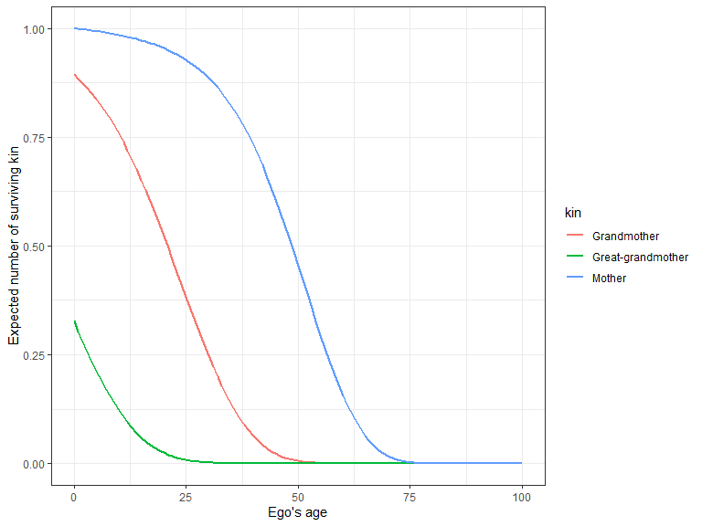

```r
stable$kins_by_age_ego %>%
  filter(kin %in% c("m", "gm", "ggm")) %>%
  rename_kin() %>%
  ggplot() +
  geom_line(aes(age_ego, total, colour = kin), size = 1)  +
  theme_bw() +
  labs(x = "Ego's age", y = "Expected number of surviving kin")
```

- **Living descendants**

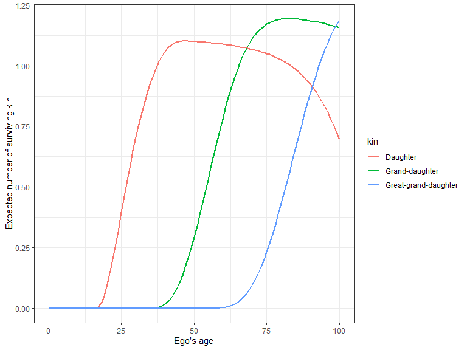

```r
stable$kins_by_age_ego %>%
  filter(kin %in% c("d", "gd", "ggd")) %>%
  rename_kin() %>%
  ggplot() +
  geom_line(aes(age_ego, total, colour = kin), size = 1)  +
  theme_bw() +
  labs(x = "Ego's age", y = "Expected number of surviving kin")
```

- **Other kin**

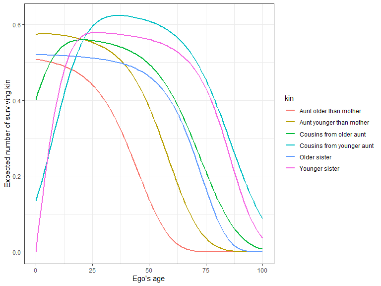

```r
stable$kins_by_age_ego %>%
  filter(kin %in% c("os", "ys", "cya", "coa", "ya", "oa")) %>%
  rename_kin() %>%
  ggplot() +
  geom_line(aes(age_ego, total, colour = kin), size = 1)  +
  theme_bw() +
  labs(x = "Ego's age", y = "Expected number of surviving kin")
```

- **Family size**: How does overall family size (and family composition) vary over life for an average woman who survives to each age?

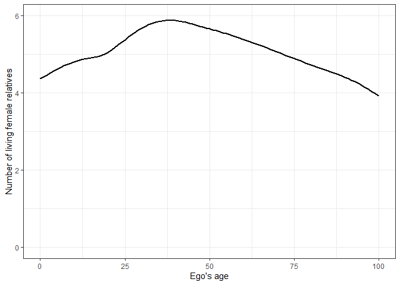

```r
stable$kins_by_age_ego %>%
  group_by(age_ego) %>%
  summarise(total = sum(total)) %>%
  ungroup() %>%
  ggplot() +
  geom_line(aes(age_ego, total), size = 1)  +
  coord_cartesian(ylim = c(0, 6)) +
  theme_bw() +
  labs(x = "Ego's age", y = "Number of living female relatives")
```

We can decompose this by relative type:

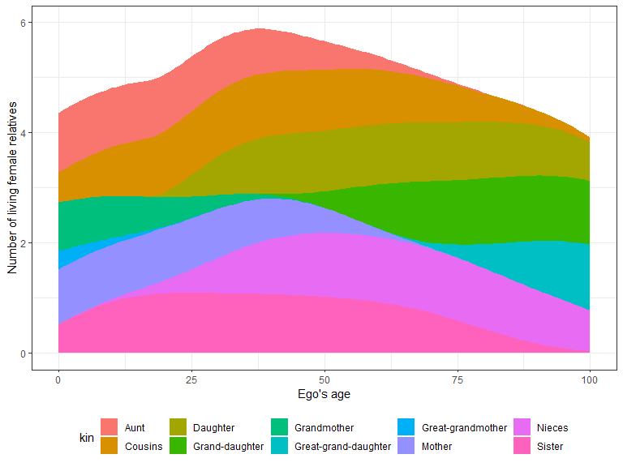

```r
# Combine kin types irrespective of whether they come from older
# or younger sibling lines
consolidate <- c("c", "c", "d", "gd", "ggd", "ggm", "gm", "m", "n", "n", "a", "a", "s", "s")
names(consolidate) <- c("coa", "cya", "d", "gd", "ggd", "ggm", "gm", "m", "nos", "nys", "oa", "ya", "os", "ys")

# Rename kin types from codes to actual words
relatives_small <- c("Cousins", "Daughter", "Grand-daughter", "Great-grand-daughter", "Great-grandmother", "Grandmother", "Mother", "Nieces", "Aunt", "Sister")
names(relatives_small) <-  unique(consolidate)

stable$kins_by_age_ego %>%
  select(age_ego, kin, total) %>%
  # Consolidate kin types
  mutate(kin = consolidate[kin]) %>%
  group_by(age_ego, kin) %>%
  summarise(total = sum(total)) %>%
  ungroup() %>%
  # Rename by hand
  mutate(kin = relatives_small[kin]) %>%
  ggplot() +
  geom_area(aes(x = age_ego, y = total, fill = kin)) +
  labs(x = "Ego's age", y = "Number of living female relatives") +
  coord_cartesian(ylim = c(0, 6)) +
  theme_bw() +
  theme(legend.position = "bottom")
```

## 2.3 Deceased kin

```r
stable_death <-
  kins(
    ego_year = 1950
    , U = swe_surv
    , f = swe_asfr
    , stable = TRUE
    , living = FALSE
    )
```

For this example, we combine all kin types to show the cumulative burden of kin death for an average member of the population surviving to each age:

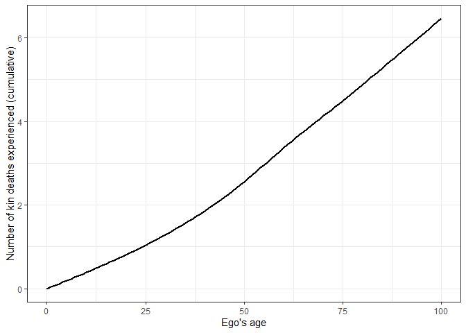

```r
stable_death$kins_alive_death %>%
  filter(alive =="no") %>%
  group_by(age_ego) %>%
  summarise(total_cum = sum(total_cum)) %>%
  ungroup() %>%
  ggplot() +
  geom_line(aes(age_ego, total_cum), size = 1)  +
  labs(x = "Ego's age", y = "Number of kin deaths experienced (cumulative)") +
  theme_bw()
```

We can decompose this by relative type:

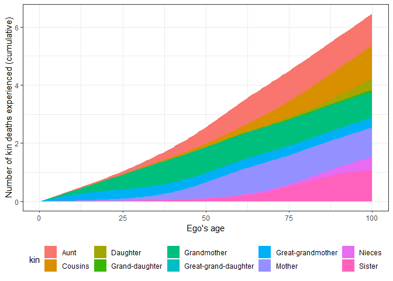

```r
stable_death$kins_alive_death %>%
  filter(alive =="no") %>%
  # Consolidate kin types
  mutate(kin = consolidate[kin]) %>%
  group_by(age_ego, kin) %>%
  summarise(total = sum(total_cum)) %>%
  ungroup() %>%
  # Rename by hand
  mutate(kin = relatives_small[kin]) %>%
  ggplot() +
  geom_area(aes(x = age_ego, y = total, fill = kin)) +
  labs(x = "Ego's age", y = "Number of kin deaths experienced (cumulative)") +
  theme_bw() +
  theme(legend.position = "bottom")
```

## 2.4 Age distribution of relatives

How old are Ego’s relatives? Using the `kin` data frame, we can visualize the age distribution of Ego’s relatives throughout Ego’s life. As an example, let’s pick three points of Ego’s life: when she’s born (age=0) at the end of her reproductive life (age=50) and when she retires (age=65).

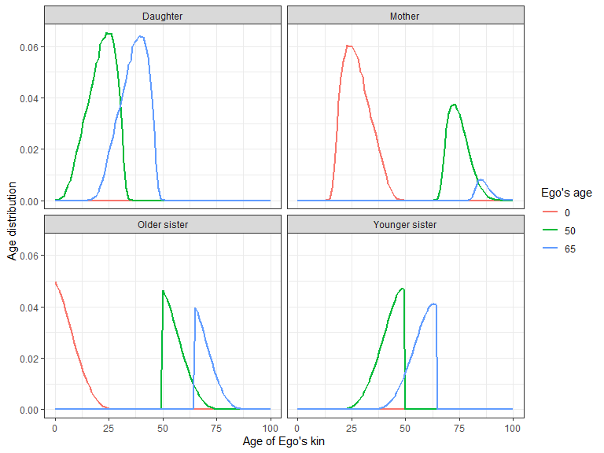

```r
stable[["kins"]] %>%
  filter(age_ego %in% c(0, 50, 65)) %>%
  filter(kin %in% c("m", "d", "os", "ys")) %>%
  mutate(age_ego = as.character(age_ego)) %>%
  rename_kin() %>%
  ggplot() +
  geom_line(aes(age_kin, count, colour = age_ego), size = 1) +
  scale_color_discrete("Ego's age") +
  labs(x = "Age of Ego's kin", y = "Age distribution") +
  theme_bw() +
  facet_wrap(~kin)
```

The output of the `DemoKin::kins()` function can also be used to easily determine the mean age Ego’s relatives by kin type. For simplicity, let’s focus on an Ego aged 35 yo and get the mean age (and standard deviation) of her relatives in our stable population.

```r
ages_df <-
  stable$kins_by_age_ego %>%
  filter(age_ego == 35) %>%
  select(kin, mean_age, sd_age)

ma <-
  ages_df %>%
  filter(kin=="m") %>%
  pull(mean_age) %>%
  round(1)

sda <-
  ages_df %>%
  filter(kin=="m") %>%
  pull(sd_age) %>%
  round(1)
```

We can say that the mothers of Ego would be, on average, 61.8 years old, with a standard deviation of 5.9 years.

# 3 Example 2: population with changing rates

The real population is Sweden is not stable: individuals in it experience changing mortality and fertility rates throughout their life. Kinship structures in populations with changing rates can be computed following Caswell (2021).

All the outputs that we showed for stable populations in the previous section are also available for non-stable populations (e.g., kin counts, deceased kin, and age distributions). In this section we’ll focus on outputs that are specific to time-varying kinship structures. In particular, we’ll show period, cohort, and age results for Sweden (Figure 5 from Caswell (2021)).

Note that, in order to arrive a this results, we use a different set of input rates, which are also pre-loaded with DemoKin.

```r
data(package="DemoKin")
```

| Item | Title |
| --- | --- |
| U (swe_caswell) |  |
| f (swe_caswell) |  |
| pi (swe_caswell) |  |

## 3.1 Cohort perspective

```r
system.time(
  swe_coh <-
    kins(
      U = U
      , f = f
      , pi = pi
      , stable = F
      , birth_female = 1
      # Note that we use the 'ego_cohort' parametersa as input
      , ego_cohort = c(1891,1911,1931,1951,1971,2011,2041)
      # We're only interested in certain kin ties
      , selected_kins = c("d","gd","m","gm")
    )
)
```

```
##    user  system elapsed
##   77.04    0.62   78.77
```

Show, in a Keyfitz diagram, the expected kin count for an average woman aged 35 and born in 1951 Sweden in a non-stable population:

```r
swe_coh$kins_by_age_ego %>%
  filter(cohort == 1951, age_ego == 35) %>%
  select(kin, total) %>%
  plot_diagram()
```

[interactive chart not shown]

Finally, we show the expected number of ascendants and descendants by Ego’s birth cohort in any given year:

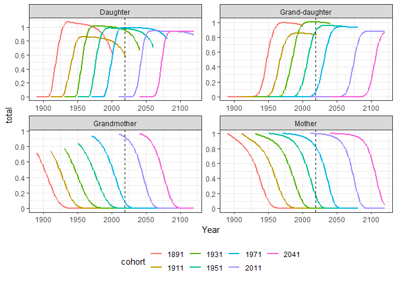

```r
swe_coh$kins_by_age_ego %>%
  rename_kin() %>%
  mutate(cohort = factor(cohort)) %>%
  ggplot(aes(year,total,color=cohort)) +
  scale_y_continuous(labels = seq(0,3,.2),breaks = seq(0,3,.2))+
  geom_line(size=1)+
  geom_vline(xintercept = 2019, linetype=2)+
  facet_wrap(~kin,scales = "free")+
  labs(x = "Year", "Kin count") +
  theme_bw() +
  theme(legend.position = "bottom")
```

## 3.2 Period perspective

For a **period perspective**, we re-run the `kins()` function, this time with a vector of `ego_year` values:

```r
system.time(
swe_period <-
  kins(
    U = U
    , f = f
    , pi = pi
    , stable = F
    , birth_female = 1
    # Note that we use the 'ego_year' parametersa as input
    , ego_year = c(1891,1921,1951,2010,2050,2080,2120)
    # We're only interested in certain kin ties
, selected_kins = c("d","gd","m","gm","os","ys")
)
)
```

```
##    user  system elapsed
##   58.70    0.17   61.67
```

Now, we plot the expected values by Ego’s age at different time-points:

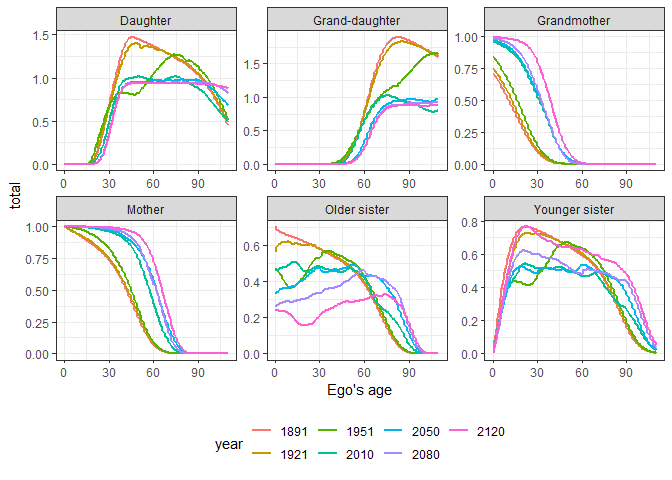

```r
swe_period$kins_by_age_ego %>%
  rename_kin() %>%
  mutate(year = factor(year)) %>%
  ggplot(aes(age_ego,total,color=year)) +
  geom_line(size=1)+
  facet_wrap(~kin, scales = "free")+
  labs(x = "Ego's age", "Kin count") +
  theme_bw() +
  theme(legend.position = "bottom")
```

# 4 In the pipeline

1. Hex logo
2. Implement multi-stage (Caswell 2020) and two-sex models (Caswell 2021)
3. Improve Keyfitz kinship diagrams
4. Create a *Human Kinship Database*?

# 5 Get involved!

`DemoKin` is giving its first steps. Please contact us via email, or create an issue or submit a pull request on GitHub (https://github.com/IvanWilli/DemoKin). You can also get in touch directly:

- Ivan:
  - ivanwilliams1985[at]gmail.com
  - https://twitter.com/ivanchowilliams
- Diego
  - alburezgutierrez[at]demogr.mpg.de
  - https://twitter.com/d_alburez
  - www.alburez.me

# 6 Citation

Williams, Iván, Alburez-Gutierrez, Diego and Xi Song. (2021) “DemoKin: An R package to compute kinship networks in stable and non-stable populations.” URL: https://github.com/IvanWilli/DemoKin.

# 7 Aknowledgments

# 8 References

# 9 Appendix: Obtaining U matrix from a life table

Here, we show how to estimate the argument **U** from `DemoKin::kins()` (survival ratio by age from a life table) from a standard life table. In this case, we are using Swedish period life tables from the Human Mortality Database.

```r
library(tidyverse)

lt <- read.table("fltper_1x10.txt", header = T, skip = 2)

lt$Age[lt$Age == "110+"] <- 110
lt$Age <- as.numeric(lt$Age)

age = 0:100
ages = length(age)
w = last(age)

# survival probabilities
L <- lt %>%
  filter(Age<=w) %>%
  mutate(Lx = ifelse(Age==w, Tx, Lx)) %>%
  select(Year, Age, Lx) %>%
  spread(Year, Lx) %>%
  select(-Age)

U <- rbind(L[c(-1,-101),]/L[-c(100:101),],
           L[101,]/(L[100,]+L[101,]),
           L[101,]/(L[100,]+L[101,]))

rownames(U) <- age
colnames(U) <- unique(lt$Year)
U[is.na(U)] <- 0

U[1:4, 1:4]
```

```
##   1751-1759 1760-1769 1770-1779 1780-1789
## 0 0.8990951 0.8959954 0.8954728 0.9046334
## 1 0.9494330 0.9520463 0.9402367 0.9476692
## 2 0.9662034 0.9679407 0.9606561 0.9650853
## 3 0.9737870 0.9734861 0.9685377 0.9726419
```

Bongaarts, John. 1987. “The Projection of Family Composition over the Life Course with Family Status Life Tables.” In *Family Demography: Methods and Their Application*, edited by John Bongaarts and Thomas Burch. Oxford: IUSSP Series, Oxford Univer- sity Pres.

Brass, W. 1953. “The Derivation of Fertility and Reproduction Rates from Restricted Data on Reproductive Histories.” *Population Studies* 7 (2): 137. https://doi.org/10.2307/2172029.

Caswell, Hal. 2021. “The Formal Demography of Kinship. IV. Two-Sex Kinship Models.” *(In Preparation)*.

———. 2019. “The Formal Demography of Kinship: A Matrix Formulation.” *Demographic Research* 41 (September): 679–712. https://doi.org/10.4054/DemRes.2019.41.24.

———. 2020. “The Formal Demography of Kinship II: Multistate Models, Parity, and Sibship.” *Demographic Research* 42 (June): 1097–1146. https://doi.org/10.4054/DemRes.2020.42.38.

Caswell, Hal, and Xi Song. 2021. “The Formal Demography of Kinship. III. Kinship Dynamics with Time-Varying Demographic Rates.” *Demographic Research* 45: 517–46.

Goodman, Leo A. 1974. “Family Formation and the Frequency of Various Kinship Relationships.” *Theoretical Population Biology*, 27. https://doi.org/10.1016/0040-5809(74)90049-5.

Keyfitz, Nathan, and Hal Caswell. 2005. *Applied Mathematical Demography*. New York: Springer.

Lotka, Alfred J. 1931. “Orphanhood in Relation to Demographic Factors.” *Metron* 9 (2): 37–109.